# Identification of quality-reflecting text features using Machine Learning Techniques

Eli-Boaz Clapper

14 January, 2022

Abstract

Rating written summaries and using the ratings as a fair proxy for text quality is a time-costly procedure that is prone to rater variability. Computerized techniques that aid the automatic scoring of text can aid the procedure. Previous research has tried to identify quality-reflecting text features to be used in automatization techniques, but the statistical models have been subject to overfitting and multicollinearity, leading to imprecise results. This thesis views the issue in a machine learning framework to help aid the rating automatization and to identify quality-reflecting text features. It is found that the linear model as well as the Elastic Net algorithms perform best, while Lasso performs worst. This is likely because only six predictors were used in this mini-thesis. It is also found that the number of words a summary contains seems to be the best predictor for the rating. Future research should use all features and all algorithms for more conclusive results.

keywords: *machine learning, summary writing, automatization*

### Introduction

In the secondary and tertiary educational years, most people recall the task of writing summaries. Summary writing has shown its merits in educational programs by aiding lingual development and improving overall academic achievement (Thiede and Anderson 2003; Gao 2013; Marzec-Stawiarska 2016; Bangert-Drowns, Hurley, and Wilkinson 2004). Rating written summaries and using the ratings as a fair proxy for text quality remains a difficult task, however. Rating written text is a time-consuming procedure and subject to notable rater variability that decreases the reliability of the ratings (Eckes 2008). Although rubrics help reduce rater variability and rating time, the issues still linger (Harsch and Martin 2013; Wiseman 2012).

A current and maybe everlasting shortage of teachers, as well as notable rater effects, call for computerized techniques that can take over the rating procedure (Sutcher, Darling-Hammond, and Carver-Thomas 2016). That is partly why much research has gone into the identification of objective text features that reflect text quality such as textual coherence and sophistication (Crossley and McNamara 2014; MacArthur, Jennings, and Philippakos 2019; McNamara, Crossley, and McCarthy 2010; McNamara, Crossley, and Roscoe 2013; Perin and Lauterbach 2018; Halliday and Hasan 2014). However, as of yet, there is no consensus which features precisely should be regarded as important and to what degree (McNamara, Crossley, and McCarthy 2010).

Conventional statistical models have tried to find the importance magnitude of text features, but rely on assumptions that are in the current interest difficult to adhere to (MacArthur, Jennings, and Philippakos 2019; McNamara, Crossley, and McCarthy 2010). This is because aforementioned models often contain a large number of features that tend to be similar to each other too (MacArthur, Jennings, and Philippakos 2019; McNamara et al. 2014). Using similar and many features introduces the issues of multicollinearity and model overfitting. Multicollinearity occurs because many similar and, as a consequence, interdependent features are used in the same statistical model. This leads to imprecise estimates of importance because this reciprocal influence makes individual relationships with the rating difficult to extract (Farrar and Glauber 1967; Alin 2010; James et al. 2013). Model overfitting occurs because of the large Features:Summaries ratio. This leads to the model parameter estimates being too dependent on the sample, which decreases predictive power in data points beyond the sample (James et al. 2013; Feng et al. 2017; Hawkins 2004).

The Machine Learning [ML] field provides statistical techniques that are either more robust against violations of assumptions or require less assumptions in general (James et al. 2013). Techniques such as regularization, cross-validation and ensemble methods help reduce overfitting and multicollinearity while simultaneously providing means to automate the rating of summaries (Jabbar and Khan 2015).

Some research has already explored the idea of ML for text feature identification (Sladoljev-Agejev and Šnajder 2017; Madnani et al. 2013; Šnajder, Sladoljev-Agejev, and Vehovec 2019). This research however, explored only a few out of many techniques, had a relatively small sample size, and used small rating scales. This thesis intends to build on previous research by exploring multiple ML techniques and posing the framework as a regression task with a larger-scaled rating. The intention is not only to identify the importance magnitude of certain text features, but also to automatize the summary rating procedure. This thesis therefore answers the following two research questions:

1. *To what extent can ML techniques automatically rate summaries?*
2. *To what extent can ML techniques identify the importance magnitude of summary text features reflecting summary text quality?*

To answer the two posed research questions it is first explained what the data set looks like (1) . Then, it is discussed which text features are extracted in this thesis (2) . Afterwards the steps undergone for pre-processing of the written summary documents are made clear (3) , and finally it is discussed which ML techniques are used and on which metrics they are evaluated (4) . Figure 1 shows a graphical representation of the thesis.

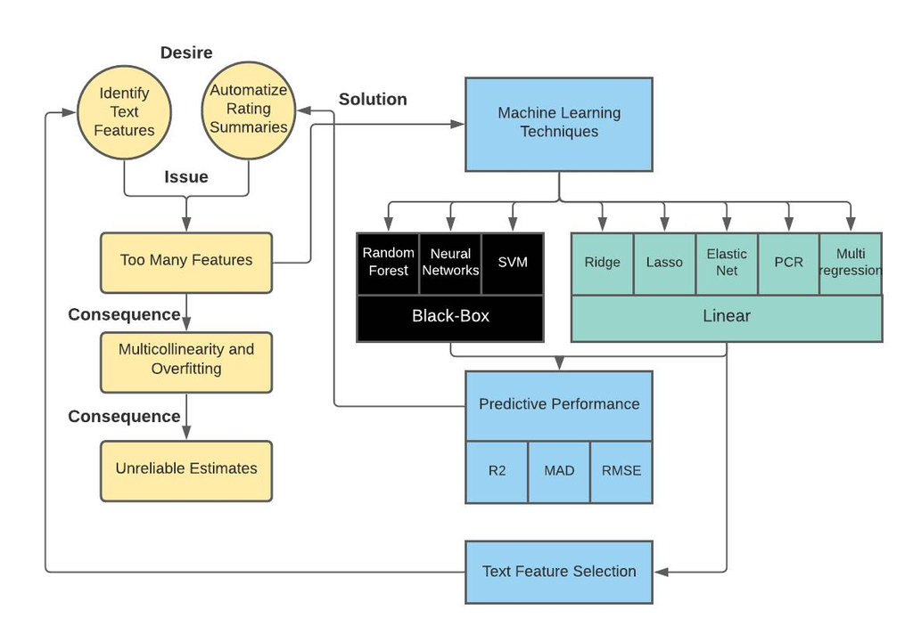

*Figure 1.* Graphical Representation of the full Thesis

### Methodology

The data set contains 970 Dutch-written summaries of a passage about seasonal allergies made by Dutch secondary and tertiary educational level students. The tracks within Dutch secondary education for which data were collected were the vocational track (in Dutch: vmbo-gt), the school of higher general secondary education (havo), and the pre-university track (vwo). Data for the tertiary educational track come from post-vocational education (mbo). The summarisation exercise was part of a set of items that assess Dutch student’s reading literacy. There are three of such sets available: 1F, 2F and 3F that respectively increase in difficulty (Haenen 2014). The summary exercise in this thesis is of level 3F and was rated by examiners using an analytic rubric. The rubric had a large focus on gist extraction and a smaller focus on textual coherence. See Appendix A for the summary exercise and Appendix B for the rubric. The summary rating ranges from 0 - 16 with higher ratings reflecting higher quality summaries. Finally, the participants were instructed to write not more than 150 words. The data set is shown in table 1

Table 1. *Raw dataset*

|  | text | schooltype | rating |
| --- | --- | --- | --- |
| 1 | De bewering van Kleenex is ongefundeerd aangezien haar bronnen niet controleerbaar zijn. De gebruikte sites en een samenwerkingsverband met Worchester University bieden beiden geen concrete antwoorden… | vwo | 10 |
| 2 | Eï¿½n op de vijf mensen heeft last van hooikoorts en dat aandeel groeit drastisch, aldus Kleenex. Deze beweringen zijn ongepundeerd. Zo worden als bronnen de EAACI, het KNMI en Allergie-site.nl genoem… | vwo | 13 |
| 3 | Wij van next.checkt vinden de bewering van Kleenex ongefundeerd Kleenex stelt dat een op de vijf mensen last heeft van hooikoorst en dat het aantal drastisch groeit. Allereerst is het ongefundeerd omd… | vwo | 11 |
| 4 | De bewering van Kleenex is ongefundeerd want het blijkt lastig om een schatting te maken van het aantal mensen met hooikoorts. Het Wordt niet bijgehouden en de klachten zijn seizoensgebonden De bronne… | vwo | 9 |
| 5 | Kleenex beweert dat een op de vijf mensen in Nederland last van hooikoorts heeft en dat dit aantal drastisch groeit. De bewering wordt als ongfundeerd beschouwd om verschillende redenen. De eerste red… | vwo | 8 |
| 6 | Volgens zakdoekjesproducent Kleenex heeft hooikoorts een hoogtepunt bereikt. Nex.checkt beoordeeld deze bewering als ongefundeerd. De uitspraak van Kleenex is gebaseerd op eigen onderzoek en uitsluite… | vwo | 13 |
| 7 | Het oordeel 'ongefundeerd' van next.checkt wordt gerechtsvaardigd omdat als bron Allergie-site.nl en de Europese Academie van Allergieï¿½n worden genoemd. Die laatste zegt het cijfer niet te herkennen… | vwo | 11 |
| 8 | De bewering van Kleenex is dat 'Een op de vijf mensen last heeft van hooikoorts en dat aantal groeit drastisch'. Next.checkt geeft aan dat deze bewering ongefungeerd is. Kleenex heeft gebruik gemaakt … | vwo | 12 |
| 9 | Zakdoekjesproducent Kleenex beweert dat hooikoorts een hoogte punt bereikt, er hebben steeds meer mensen last van. Het is een groeiend probleem. Maar niemand houdt de daadwerkelijke aantallen bij. Hoo… | vwo | 5 |
| 10 | Kleenex beweert dat een op de vijf mensen last heeft van hooikoorts en dat dit aantal drastisch groeit. Als bron worden de de EAACI en Allergie-site.nl genoemd. Die laatste bestaat niet langer en een … | vwo | 12 |

[output cut: 960 more lines]

### Used Text Features

A number of text features will be calculated. Because the rubric was focused on gist extraction and textual coherence, some calculated features are either theorized or have practical support to be reflective of at least one of these dimensions (Sabatini, O’Reilly, and Deane 2013; Madnani et al. 2013; McNamara, Crossley, and McCarthy 2010; Pander Maat et al. 2014). Other features do not necessarily reflect gist extraction or coherence, but may predict rating due to subjective differences in rater judgements, i.e. rater variability not explained by the rubric (McNamara, Crossley, and McCarthy 2010; Kleijn 2018). The features that will be calculated are:

- *Wordlength*: The number of words in a summary.
- *Sentlength*: The number of sentences in a summary,
- *MaxCopy*: The length of the longest common substring. The longest common substring is the length of the most consecutive words in the summary copied from the passage.
- *Rouge* (Recall-oriented understudy for gisting evaluation): Rouge is an algorithm developed by Lin and Hovy (2003) to automatically evaluate summaries based on n-gram co-occurrence with a model summary. A model summary in this thesis is a randomly sampled summary that got the highest rating. Rouge scores up until *Rouge3* are calculated.

*MaxCopy* and *Rouge* reflect gist extraction. *SentLength* and *WordLength* may explain rater variability not explained by the rubric.

### Data pre-processing

The calculation of the text features can depend on a particular processed stage of the text documents. That is why first a list is provided with general processing steps and used software. Afterwards it is explained which of the pre-processing steps are required and altered to calculate the features. The list of pre-processing steps is as follows:

1. Text characters are encoded to the correct format.
2. Punctuation is removed
3. Redundant white spaces are removed.
4. All words are made lowercase.

*Rouge, MaxCopy* and *Wordlength* require all steps to be applied in the order they are presented in. For *Sentlength* the steps only need to be followed ending with step 3, where during step 2 the dots, exclamation- and question marks are retained and semicolons are replaced with dots.

Because the gist extraction features depend on exact N-gram copies of the passage or summary, stemming/lemmatization and stop-word removal are not desired. Furthermore, the output of this stage is a matrix containing the ratings and the text features of which the latter will be standardized prior to analysis. This matrix, thus not containing string values, serve as input for the ML algorithms. This means that processing steps that are typically needed for Bag-Of-Word models, such as stop word removal and stemming/lemmatization are not required. The matrix that serves as input for the ML algorithms is shown in table 2.

Table 2. *Input matrix for the ML algorithms*

| Rating | Sentlength | rouge1 | rouge2 | rouge3 | WordLength | MaxCopy |
| --- | --- | --- | --- | --- | --- | --- |
| 10 | -0.01 | -0.68 | -0.49 | -0.63 | 1.18 | -0.69 |
| 13 | 1.25 | 0.19 | 0.12 | -0.46 | 1.37 | 0.19 |
| 11 | -0.01 | -0.4 | -0.73 | -0.77 | 1.18 | -0.86 |
| 9 | -0.33 | 0.7 | 1.5 | 1.59 | 1.21 | 1.6 |
| 8 | -0.01 | -0.13 | -0.52 | -0.57 | 0.38 | -0.86 |
| 13 | 2.19 | 0.68 | 0.39 | 0.07 | 1.37 | 0.37 |
| 11 | 1.88 | -0.04 | 0.79 | 1.05 | 1.27 | 0.9 |
| 12 | 2.51 | -0.52 | -0.73 | -0.68 | 1.21 | -0.33 |
| 5 | -0.33 | 0.62 | 0 | -0.32 | -0.96 | -0.69 |
| 12 | 1.25 | 0.58 | 0.67 | 0.23 | 1.27 | 2.13 |

[output cut: 960 more lines]

All pre-processing and the calculation of *SentLength* will be performed in R (version 4.1.2) within Rstudio IDE (version 1.4.17.17) (R Core Team 2013; Team 2021). The other feature calculations will be performed in Python 3.9.0 within Rstudio IDE.

### ML techniques and performance metrics

In total, five ML techniques are used to answer the research questions. These five algorithms produce models for which variable importance can be extracted. These techniques include Ridge-, Lasso-, Elastic net-, Linear Principle Component Regression [LPCR], and Multivariate Linear Regression [MLR] of which the first three are available in package `glmnet` with function `glmnet()` and the latter two are available in the `stats` package with functions `lm()` and `prcomp()` provided by R Core Team (Friedman, Hastie, and Tibshirani 2010; R Core Team 2013). `glmnet()` minimizes the following Residual Sum of Squares [RSS]:

$$\begin{align}
RSS_{ElasticNet} &= \frac{1}{N} \sum_{i=1}^{N} (y_i - \beta_0+\boldsymbol{\beta}^T x_i) + \lambda\left[(1-\alpha)\|\boldsymbol{\beta}\|_2^2/2 + \alpha \|\boldsymbol{\beta}\|_1\right] \\
RSS_{Ridge} &= \frac{1}{N} \sum_{i=1}^{N} (y_i - \beta_0+\boldsymbol{\beta}^T x_i) + \lambda(\|\boldsymbol{\beta}\|_2^2/2) \\
RSS_{Lasso} &= \frac{1}{N} \sum_{i=1}^{N} (y_i - \beta_0+\boldsymbol{\beta}^T x_i) + \lambda\| \boldsymbol{\beta}\|_1
\end{align}$$

with respect to $\beta_0$ and $\beta^T$ where $\alpha$ is the tuning parameter for elastic net that determines the amount of Lasso or Ridge regression. Setting $\alpha = 0$ or $\alpha = 1$ defines $RSS$ for Ridge and Lasso Respectively.

These techniques were chosen because of their ability for regularization or data reduction, which reduces multicollinearity. These techniques are intended to identify the importance magnitude of text features while dealing with multicollinearity and overfitting. MLR is used as a benchmark to compare performance of the other algorithms to.

All algorithms are evaluated using 10-fold Cross-Validation [CV] with the data set first being split up in a train, and test set with respective proportions .60-.40. The hyperparameters are optimized using grid search on the validation sets. Some hyperparameters have fixed default values in their respective algorithms that will not be tuned. The hyperparameters that are varied or deviate from default are shown in table 3, along with their interpretation. The choice for the varying values for the hyperparameters are based on a balance between computational time and research suggested values to improve performance on high-dimensional multicollinear data (Probst and Boulesteix 2017; Goldstein, Polley, and Briggs 2011; Probst, Wright, and Boulesteix 2019; Stathakis 2009; Obite et al. 2020; Farrell et al. 2019; Wainer and Fonseca 2021). The parameters that lead to best model performance will be used to train the models on the entire training set. The models are then tested on the test set to obtain the final metrics of evaluation.

Table 3. *Varying and default-deviating hyperparameters*

| Algorithm | Parameter | Interpretation | Value |
| --- | --- | --- | --- |
| Lasso/Ridge | $\lambda$ | Amount of regularization | default in `glmnet()` |
| Elastic Net | $\lambda$ | Amount of regularization | default in `glmnet()` |
|  | $\alpha$ | Amount of L1-L2 regularization | 0.1-0.9 |
| LPCR | $n_{pc}$ | Number of extracted PC’s | 1-4 |

All algorithms are evaluated on three predictive performance metrics that determine their usability in automatically scoring summaries. Those metrics are the proportion of explained variance in the human ratings by the model: $R^2$, the Root of the Mean Squared Error: $RMSE$, and the Mean Absolute Deviation: $MAD$. The algorithms are additionally investigated on which features/principle components are selected as relevant. Relevance is in turn defined for Lasso when the algorithm selects a feature, for MLR when a regression coefficient does not contain 0 in its 95% confidence interval, for Ridge and Elastic Net when the absolute regression coefficient > .05. Additionally, for PCR, a text feature is regarded as important if its factor loading $\geq$ .20 on at least one of the selected principle components. Both $MAD$ and $RMSE$ are used as $MAD$ is more robust against outliers. $R^2$ is used to determine how much variance in the ratings can be explained by the used text features. $RMSE$ will be the leading metric to determine predictive performance.

All analyses will be performed in R (version 4.1.2) using Rstudio IDE (version 1.4.1717).

### Results

#### **Predictive performance**

The ability of the algorithms to correctly predict new data points was determined by looking at the $R^2$, $MAD$ and $RMSE$ values they produced. The results indicate that the MLR and Elastic Net algorithms performed best $R^2 = 0.57$, $MAD = 1.71$, $RMSE = 2.27$, closely followed by ridge regression, $R^2 = 0.56$, $MAD = 1.74$, $RMSE = 2.28$ and LPCR, $R^2 = 0.50$, $MAD = 1.89$, $RMSE = 2.42$. Lasso performed worst: $R^2 = 0.34$, $MAD = 2.29$, $RMSE = 2.8$. Table 4 shows the results

Table 4. *Predictive performance of algorithms*

|  | RMSE | MAD | R2 |
| --- | --- | --- | --- |
| metrics_EN | 2.27 | 1.71 | 0.57 |
| metrics_lasso | 2.8 | 2.29 | 0.34 |
| metrics_lm | 2.27 | 1.71 | 0.57 |
| metrics_lpcr | 2.42 | 1.89 | 0.5 |
| metrics_ridge | 2.28 | 1.74 | 0.56 |

#### **Feature selection**

It was also investigated how often certain features were selected as relevant by the algorithms. Figure 2 shows the results.

*Figure 2.* Feature importance

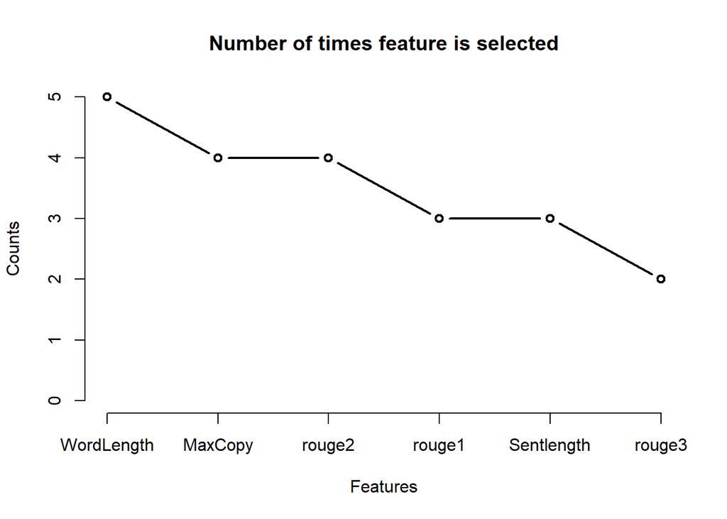

# References

Alin, Aylin. 2010. “Multicollinearity.” *Wiley Interdisciplinary Reviews: Computational Statistics* 2 (3): 370–74.

Bangert-Drowns, Robert L, Marlene M Hurley, and Barbara Wilkinson. 2004. “The Effects of School-Based Writing-to-Learn Interventions on Academic Achievement: A Meta-Analysis.” *Review of Educational Research* 74 (1): 29–58.

Crossley, Scott A, and Danielle S McNamara. 2014. “Does Writing Development Equal Writing Quality? A Computational Investigation of Syntactic Complexity in L2 Learners.” *Journal of Second Language Writing* 26: 66–79.

Eckes, Thomas. 2008. “Rater Types in Writing Performance Assessments: A Classification Approach to Rater Variability.” *Language Testing* 25 (2): 155–85.

Farrar, Donald E, and Robert R Glauber. 1967. “Multicollinearity in Regression Analysis: The Problem Revisited.” *The Review of Economic and Statistics*, 92–107.

Farrell, Annie, Guiming Wang, Scott A Rush, James A Martin, Jerrold L Belant, Adam B Butler, and Dave Godwin. 2019. “Machine Learning of Large-Scale Spatial Distributions of Wild Turkeys with High-Dimensional Environmental Data.” *Ecology and Evolution* 9 (10): 5938–49.

Feng, Xiaoyue, Yanchun Liang, Xiaohu Shi, Dong Xu, Xu Wang, and Renchu Guan. 2017. “Overfitting Reduction of Text Classification Based on AdaBELM.” *Entropy* 19 (7): 330.

Friedman, Jerome, Trevor Hastie, and Robert Tibshirani. 2010. “Regularization Paths for Generalized Linear Models via Coordinate Descent.” *Journal of Statistical Software* 33 (1): 1–22. https://www.jstatsoft.org/v33/i01/.

Gao, Yang. 2013. “The Effect of Summary Writing on Reading Comprehension: The Role of Mediation in EFL Classroom.” *Reading Improvement* 50 (2): 43–47.

Goldstein, Benjamin A, Eric C Polley, and Farren BS Briggs. 2011. “Random Forests for Genetic Association Studies.” *Statistical Applications in Genetics and Molecular Biology* 10 (1).

Haenen, Pascalle. 2014. “Referentieset Taal En Lezen.” Utrecht, Netherlands: College voor Toetsen en Examens; [http://www.toetsspecials.nl/html/referentiesets_openbaar/taal.shtm](http://www.toetsspecials.nl/html/referentiesets_openbaar/taal.shtm  
) .

Halliday, Michael Alexander Kirkwood, and Ruqaiya Hasan. 2014. *Cohesion in English*. 9. Routledge.

Harsch, Claudia, and Guido Martin. 2013. “Comparing Holistic and Analytic Scoring Methods: Issues of Validity and Reliability.” *Assessment in Education: Principles, Policy & Practice* 20 (3): 281–307.

Hawkins, Douglas M. 2004. “The Problem of Overfitting.” *Journal of Chemical Information and Computer Sciences* 44 (1): 1–12.

Jabbar, H, and Rafiqul Zaman Khan. 2015. “Methods to Avoid over-Fitting and Under-Fitting in Supervised Machine Learning (Comparative Study).” *Computer Science, Communication and Instrumentation Devices*, 163–72.

James, Gareth, Daniela Witten, Trevor Hastie, and Robert Tibshirani. 2013. *An Introduction to Statistical Learning*. Vol. 112. Springer.

Kleijn, Suzanne. 2018. *Clozing in on Readability: How Linguistic Features Affect and Predict Text Comprehension and on-Line Processing*. LOT.

Lin, Chin-Yew, and Eduard Hovy. 2003. “Automatic Evaluation of Summaries Using n-Gram Co-Occurrence Statistics.” In *Proceedings of the 2003 Human Language Technology Conference of the North American Chapter of the Association for Computational Linguistics*, 150–57.

MacArthur, Charles A, Amanda Jennings, and Zoi A Philippakos. 2019. “Which Linguistic Features Predict Quality of Argumentative Writing for College Basic Writers, and How Do Those Features Change with Instruction?” *Reading and Writing* 32 (6): 1553–74.

Madnani, Nitin, Jill Burstein, John Sabatini, and Tenaha O’Reilly. 2013. “Automated Scoring of Summary-Writing Tasks Designed to Measure Reading Comprehension.” *Grantee Submission*.

Marzec-Stawiarska, Małgorzata. 2016. “The Influence of Summary Writing on the Development of Reading Skills in a Foreign Language.” *System* 59: 90–99.

McNamara, Danielle S, Scott A Crossley, and Philip M McCarthy. 2010. “Linguistic Features of Writing Quality.” *Written Communication* 27 (1): 57–86.

McNamara, Danielle S, Scott A Crossley, and Rod Roscoe. 2013. “Natural Language Processing in an Intelligent Writing Strategy Tutoring System.” *Behavior Research Methods* 45 (2): 499–515.

McNamara, Danielle S, Arthur C Graesser, Philip M McCarthy, and Zhiqiang Cai. 2014. *Automated Evaluation of Text and Discourse with Coh-Metrix*. Cambridge University Press.

Obite, CP, NP Olewuezi, GU Ugwuanyim, and DC Bartholomew. 2020. “Multicollinearity Effect in Regression Analysis: A Feed Forward Artificial Neural Network Approach.” *Asian Journal of Probability and Statistics*, 22–33.

Pander Maat, Henk, Rogier Kraf, APJ van den Bosch, Nick Dekker, M van Gompel, S de Kleijn, Ted Sanders, and K Sloot. 2014. “T-Scan: A New Tool for Analyzing Dutch Text.”

Perin, Dolores, and Mark Lauterbach. 2018. “Assessing Text-Based Writing of Low-Skilled College Students.” *International Journal of Artificial Intelligence in Education* 28 (1): 56–78.

Probst, Philipp, and Anne-Laure Boulesteix. 2017. “To Tune or Not to Tune the Number of Trees in Random Forest.” *J. Mach. Learn. Res.* 18 (1): 6673–90.

Probst, Philipp, Marvin N Wright, and Anne-Laure Boulesteix. 2019. “Hyperparameters and Tuning Strategies for Random Forest.” *Wiley Interdisciplinary Reviews: Data Mining and Knowledge Discovery* 9 (3): e1301.

R Core Team. 2013. *R: A Language and Environment for Statistical Computing*. Vienna, Austria: R Foundation for Statistical Computing. http://www.R-project.org/.

Sabatini, John, Tenaha O’Reilly, and Paul Deane. 2013. “Preliminary Reading Literacy Assessment Framework: Foundation and Rationale for Assessment and System Design.” *ETS Research Report Series* 2013 (2): i–50.

Sladoljev-Agejev, Tamara, and Jan Šnajder. 2017. “Using Analytic Scoring Rubrics in the Automatic Assessment of College-Level Summary Writing Tasks in L2.” In *Proceedings of the Eighth International Joint Conference on Natural Language Processing (Volume 2: Short Papers)*, 181–86.

Stathakis, Dimitris. 2009. “How Many Hidden Layers and Nodes?” *International Journal of Remote Sensing* 30 (8): 2133–47.

Sutcher, Leib, Linda Darling-Hammond, and Desiree Carver-Thomas. 2016. “A Coming Crisis in Teaching? Teacher Supply, Demand, and Shortages in the US.” *Learning Policy Institute*.

Šnajder, Jan, Tamara Sladoljev-Agejev, and Svjetlana Kolić Vehovec. 2019. “Analysing Rhetorical Structure as a Key Feature of Summary Coherence.” In *Proceedings of the Fourteenth Workshop on Innovative Use of NLP for Building Educational Applications*, 46–51.

Team, RStudio. 2021. *RStudio: Integrated Development Environment for r*. Boston, MA: RStudio, PBC. http://www.rstudio.com/.

Thiede, Keith W, and Mary CM Anderson. 2003. “Summarizing Can Improve Metacomprehension Accuracy.” *Contemporary Educational Psychology* 28 (2): 129–60.

Wainer, Jacques, and Pablo Fonseca. 2021. “How to Tune the RBF SVM Hyperparameters? An Empirical Evaluation of 18 Search Algorithms.” *Artificial Intelligence Review*, 1–27.

Wiseman, Cynthia S. 2012. “A Comparison of the Performance of Analytic Vs. Holistic Scoring Rubrics to Assess L2 Writing.” *International Journal of Language Testing* 2 (1): 59–92.

# Appendix A

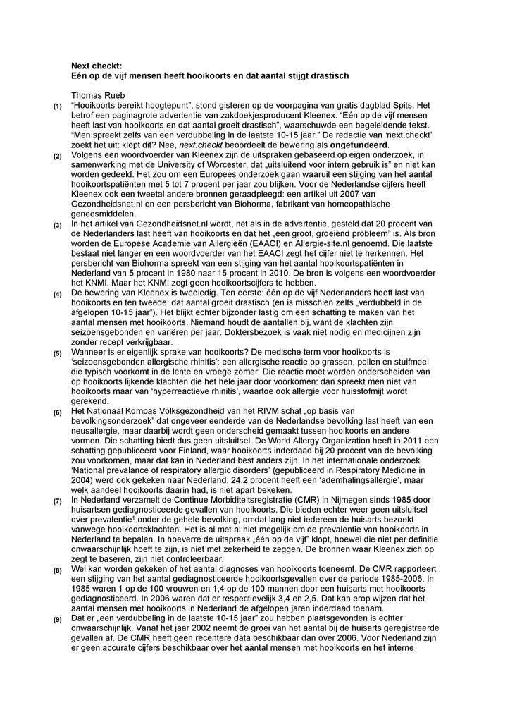

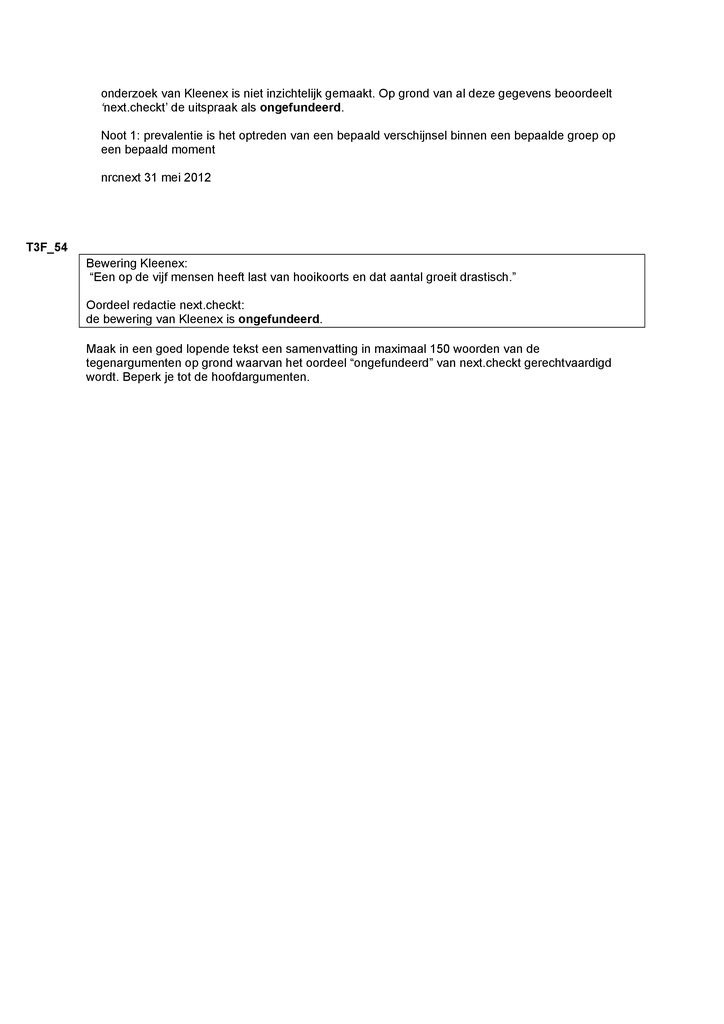

# Appendix B

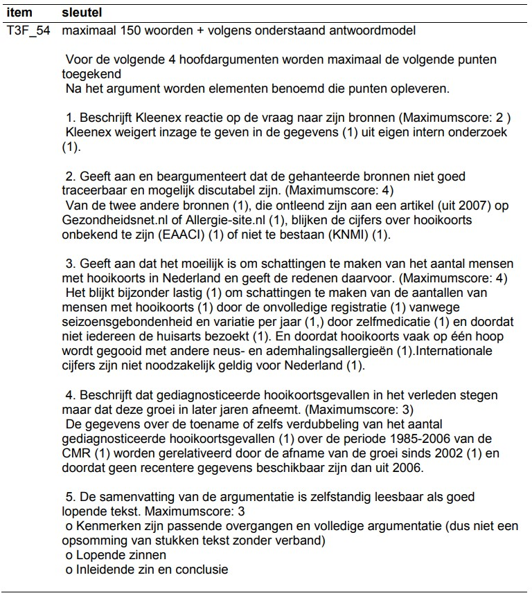